# Dimensionality_Reduction_for_Multimedia_Data

**1. List down all possible dimensionality reduction techniques that can be implemented using python.**

Following are the dimensional reduction techniques.

1. High Correlation
2. Random Forest
3. Common Dimensionality Reduction where just by analysis we can reduce the dimensions by just matching co-relation or some ordinal values that does not have a relevance in the model building.
4. Missing values, columns with much of the NaN values where is a majority.
5. Principal Component Analysis

**2. So far you have used dimensional reduction on numeric data. Is it possible to do the same on a multimedia data [images and video] and text data ? Please illustrate your findings using a simple implementation on python**

It is possible to perform multimedia dimensionality reduction. As the image data contains a vector of pixel data each comprising of the magnitude which we use to formulate for our final analysis and we can use it to reduce the dimension thereby decomposing the data .

```python
# importing Libraries
import matplotlib.pyplot as plt
import matplotlib.image as mim
import numpy as np
from sklearn.decomposition import PCA
```

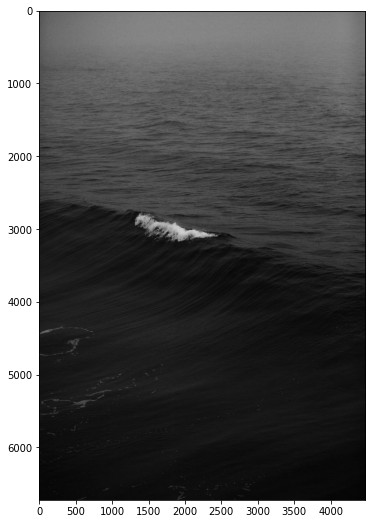

```python
#Read the image
img=mim.imread('image.jpg')

#Show image
plt.figure(figsize=(10,9))
plt.imshow(img);
```

```python
#Reshape the image size to understandable format.
print("Row of original image :",img.shape[0])
print("Number of pixels of original image :",img.shape[1:])

#We will convert the Number of pixels corresponding to each rows into number of columns
img_re=np.reshape(img,(img.shape[0],img.shape[1]*img.shape[2]))
print("Shape of reshaped image :",img_re.shape)

#PCA with 20 components and transform the image
pca=PCA(n_components=20);

#fitting the reshaped image in the model.
pca.fit(img_re);

#Transforming the axes of the already existing data into newer axis decided by eigen vectors therby leading to a reduction in the variance.
img_trans=pca.transform(img_re)
print("Transformed Image shape :",img_trans.shape)

#Image Transformation to recreate original dimension
img_Inv=pca.inverse_transform(img_trans)

#Reshaping image back with same r,g,b components
final_img=np.reshape(img_Inv,(img.shape[0],img.shape[1],img.shape[2]))
```

```
Row of original image : 6720
Number of pixels of original image : (4480, 3)
Shape of reshaped image : (6720, 13440)
Transformed Image shape : (6720, 20)
```

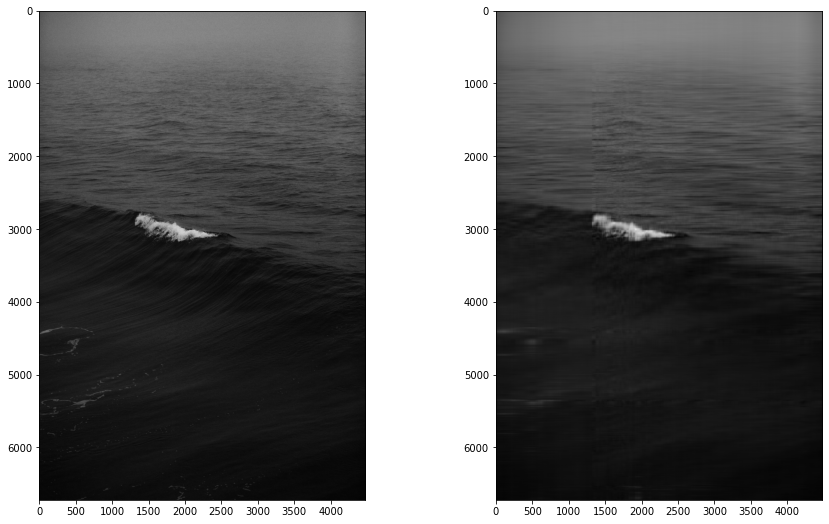

```python
#Displaying final image
plt.figure(figsize=(15,9))
plt.subplot(1,2,1)
plt.imshow(img)
plt.subplot(1,2,2)
plt.imshow(final_img.astype('uint8'))
plt.show()
```

Therefore, We can almost replicate the original image with reducing the dimensions to 20